# Overview suicide

Axel-Cleris Gailloty

2019-05-22

According to the [WHO Suicides organization](https://www.who.int/news-room/fact-sheets/detail/suicide), 800.000 committed suicide in 2018. This means every 40 seconds a person dies by suicide. This number is fortunately dropping. In this kernel I want to explore the evolution of suicide rate using the dataset provided here on Kaggle.  
I’ll be using the powerful R language to do this analysis, my main focus is to understand what affects the suicide rate to decrease.

Let’s start by loading the packages we’ll be using throughout this study.

```r
suicide <- read.csv("master.csv")
# Fix the column name of country
colnames(suicide)[colnames(suicide) == "ï..country"] <- "country"
```

```r
suicide %>% head
```

```
##   country year    sex         age suicides_no population suicides.100k.pop
## 1 Albania 1987   male 15-24 years          21     312900              6.71
## 2 Albania 1987   male 35-54 years          16     308000              5.19
## 3 Albania 1987 female 15-24 years          14     289700              4.83
## 4 Albania 1987   male   75+ years           1      21800              4.59
## 5 Albania 1987   male 25-34 years           9     274300              3.28
## 6 Albania 1987 female   75+ years           1      35600              2.81
##   country.year HDI.for.year gdp_for_year.... gdp_per_capita....
## 1  Albania1987           NA    2,156,624,900                796
## 2  Albania1987           NA    2,156,624,900                796
## 3  Albania1987           NA    2,156,624,900                796
## 4  Albania1987           NA    2,156,624,900                796
## 5  Albania1987           NA    2,156,624,900                796
## 6  Albania1987           NA    2,156,624,900                796
##        generation
## 1    Generation X
## 2          Silent
## 3    Generation X
## 4 G.I. Generation
## 5         Boomers
## 6 G.I. Generation
```

# Data exploration

In this section we are going to explore the data in order to find insights.

Do we have any missing data ?

```r
sapply(suicide, is.na) %>% colSums
```

```
##            country               year                sex
##                  0                  0                  0
##                age        suicides_no         population
##                  0                  0                  0
##  suicides.100k.pop       country.year       HDI.for.year
##                  0                  0              19456
##   gdp_for_year.... gdp_per_capita....         generation
##                  0                  0                  0
```

Only the `HDI.for.year` column contains missing values. What is the proportion of missing data in this column?

```r
sum(is.na(suicide$HDI.for.year))/length(suicide$HDI.for.year) * 100
```

```
## [1] 69.9353
```

Near 70 % of the data is missing for this column. We’ll see how we can make use of this variable.

## QUalitative variables frequencies

## Génération

```r
suicide %>% group_by(generation) %>%
summarize(nb = n())
```

```
## # A tibble: 6 x 2
##   generation         nb
##   <fct>           <int>
## 1 Boomers          4990
## 2 G.I. Generation  2744
## 3 Generation X     6408
## 4 Generation Z     1470
## 5 Millenials       5844
## 6 Silent           6364
```

These are the number of occurences of each generation in the dataset.

```r
hcbar(x = suicide$generation, name = "Génération") %>%
hc_add_theme(hc_theme_economist())
```

[interactive chart not shown]

X generation and silent are the most popular. Generation Z is the smallest group.

Let’s now visualize the age groups

```r
hcbar(x = suicide$age, name = " ge") %>%
hc_add_theme(hc_theme_economist())
```

[interactive chart not shown]

The age groups are all equally distributed.

How about the the sex group. They both are equally distributed

```r
hcbar(x = suicide$sex, name = "Sexe") %>%
hc_add_theme(hc_theme_economist())
```

[interactive chart not shown]

Now do we have the same amount of data for each year ?

```r
hcbar(x = as.character(suicide$year), name = "Years") %>%
hc_add_theme(hc_theme_economist())
```

[interactive chart not shown]

The dataset does not have all the data for each year. Each year varies. For example the last year 2016 has the fewest records. We need to keep this information in mind when we want to interpret the results of the analysis. # Visualization

In this section we are going to visualize the data.

```r
theme_set(theme_economist())
```

Pour commencer regardons l’évolution mondiale du taux de suicide par catégorie d’âge et par sexe.

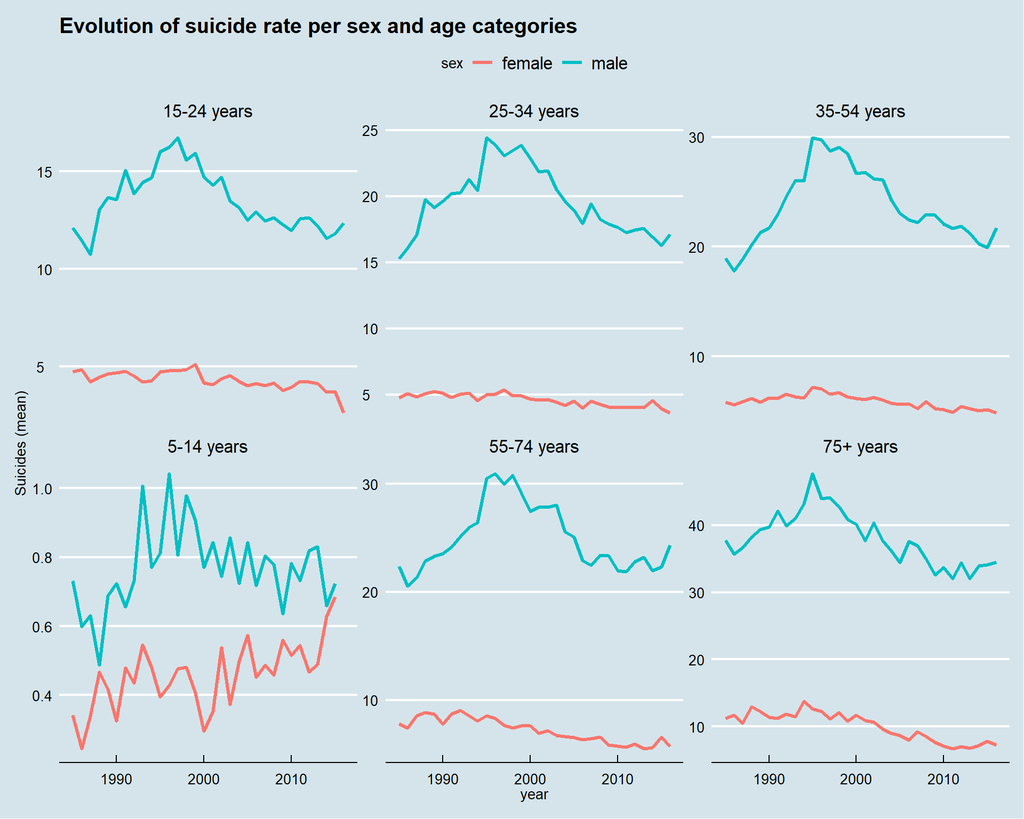

This graphs displays a lot of information. For all the times, all the age groups the suicide rate is higher for men than women. This means that the variable `sex` differentiates the population of this dataset. We can check this with an analysis of variance.

## Analysis of variance (ANOVA)

```r
temp <- suicide %>% group_by(year,sex, age) %>%
summarize(moy_suicide = mean(suicides.100k.pop))
fit <- aov(formula = moy_suicide~age+sex, data = temp)
summary(fit)
```

```
##              Df Sum Sq Mean Sq F value Pr(>F)
## age           5  19222    3844   171.4 <2e-16 ***
## sex           1  20754   20754   925.1 <2e-16 ***
## Residuals   375   8413      22
## ---
## Signif. codes:  0 '***' 0.001 '**' 0.01 '*' 0.05 '.' 0.1 ' ' 1
```

There’s a statistically significant difference between the two groups (men and women). This difference is stronger than the age group. (Look at the F value, by default R doesn’t print numbers < to 2e-16)

## Correlation between pairs of quantitative variables

```r
library(ggcorrplot)
```

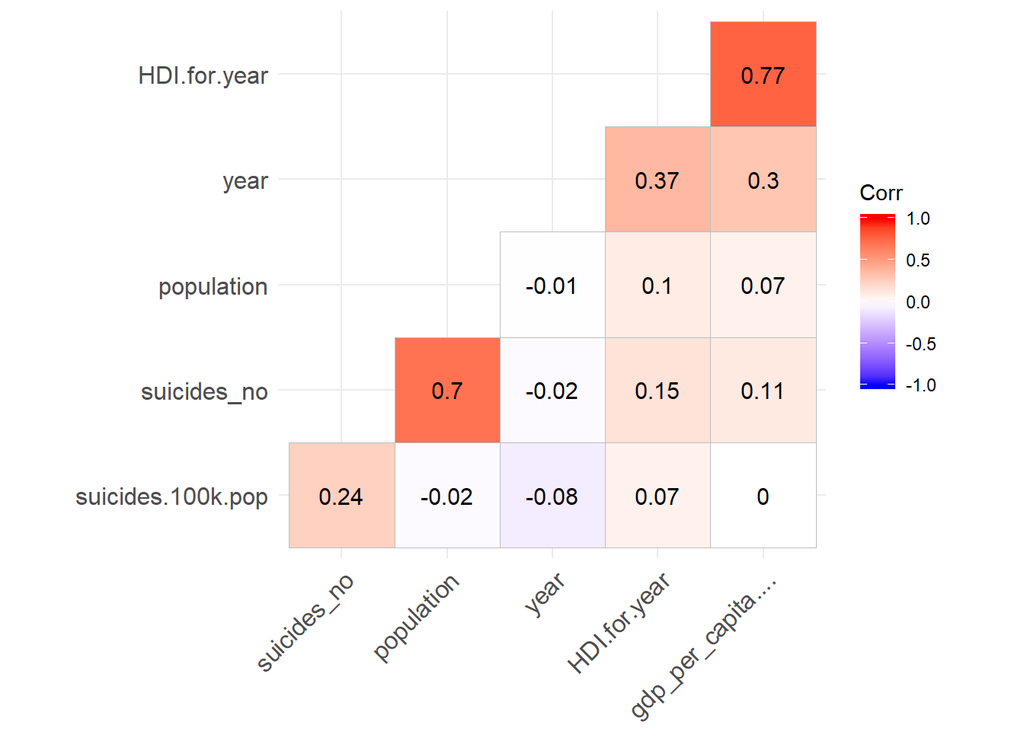

```r
options(repr.plot.height = 4, repr.plot.res = 180, repr.plot.width = 6)
suicide[,sapply(suicide, is.numeric)] %>%
cor(use = "complete.obs") %>% ggcorrplot(hc.order = TRUE, type = "lower",
   lab = TRUE)
```

## Let’s use the variable GDP for year (gross domestic product of the year)

A priori this variable is not in a numeric format. Considering the case of Albania in 1987, we have a GDP for men of 15-24 of 2,156,624,900. it does not mean anything because the GDP does not depend on a category of the population. This number is repeated for all age categories.

We will therefore correct this variable in order to use it in the following analysis

In order for us to be able to use this variable, we will divide the GDP by age group, so we can easily sum them up when we group the data.

```r
suicide$gdp <- gsub(",","",suicide$gdp_for_year....) %>% as.numeric()
gdp <- suicide %>% group_by(country, year) %>%
summarize(occurence = n(), gdp = sum(gdp)) %>% mutate(real_gdp = gdp/occurence)
```

```r
france <- gdp %>% filter(country == "France")
germany <- gdp %>% filter(country == "Germany")
canada <- gdp %>% filter(country == "Canada")
```

[interactive chart not shown]

We can now use this variable for the rest of our study since we know it represents the GDP. We could verify it by multiplying the GDP per capita by the population.

Let’s continue to visualize the data by creating treemaps so we can see the importance of each country according to the numerical variables of the dataset.

```r
gdp_2014 <- suicide %>% group_by(country, year) %>%
summarize(occurence = n(), gdp = sum(gdp)) %>% mutate(real_gdp = gdp/occurence) %>%
filter(year == 2014)
```

[interactive chart not shown]

The US economy is really big. But China and India which also are big economies are missing in the dataset leaving Japan to be the second world highest GDP.  
Let’s plot this same treemap but with GDP per capita to see how things change.

[interactive chart not shown]

Things have changed since Luxembourg and Norway are the countries with the highest GDP per capita.

Let’s now see which are the countries with highest suicide rates that year.

```r
suicide_2014 <- suicide %>% group_by(country, year) %>%
summarize( count = n(), population = sum(population), suicide_total = sum(suicides.100k.pop)) %>%
filter(year == 2014)
```

[interactive chart not shown]

Lithuania, South Korea and Suriname have the highest suicide rates in 2014.

# How the suicides rates have evolved ?

Now I want to compare for each available country in the dataset how the suicides rates have evolved during a long period of time.  
I learn to make the following graph thanks to this [beautiful kernel](https://www.kaggle.com/janiobachmann/price-of-avocados-pattern-recognition-analysis) of [Janio Martinez Bachmann](https://www.kaggle.com/janiobachmann).

```r
mixed_df <- suicide %>% group_by(country, year, sex) %>%
summarize(nb_occurence = n(), nb_suicide = sum(suicides.100k.pop)) %>% data.frame %>%
spread_(key_col = "year", value_col = "nb_suicide") %>% select(country, sex, "1986", "2014") %>% na.omit
```

```r
colnames(mixed_df) <- c("country", "sex", "yr_1986", "yr_2014")
comparison_mixed_df <- mixed_df %>%
mutate(difference = yr_2014 - yr_1986,
       pct = difference/yr_1986*100,
       variation = ifelse(difference >0, "Positive", "Negative"))
```

```r
head(comparison_mixed_df)
```

```
##               country    sex yr_1986 yr_2014 difference        pct
## 1 Antigua and Barbuda female    0.00    0.00       0.00        NaN
## 2 Antigua and Barbuda   male    0.00    0.00       0.00        NaN
## 3           Argentina female   32.01   19.48     -12.53 -39.144017
## 4           Argentina   male  120.89   91.87     -29.02 -24.005294
## 5           Australia female   35.38   34.88      -0.50  -1.413228
## 6           Australia   male  140.41  114.19     -26.22 -18.673884
##   variation
## 1  Negative
## 2  Negative
## 3  Negative
## 4  Negative
## 5  Negative
## 6  Negative
```

Let’s now use ggplot to plot it.

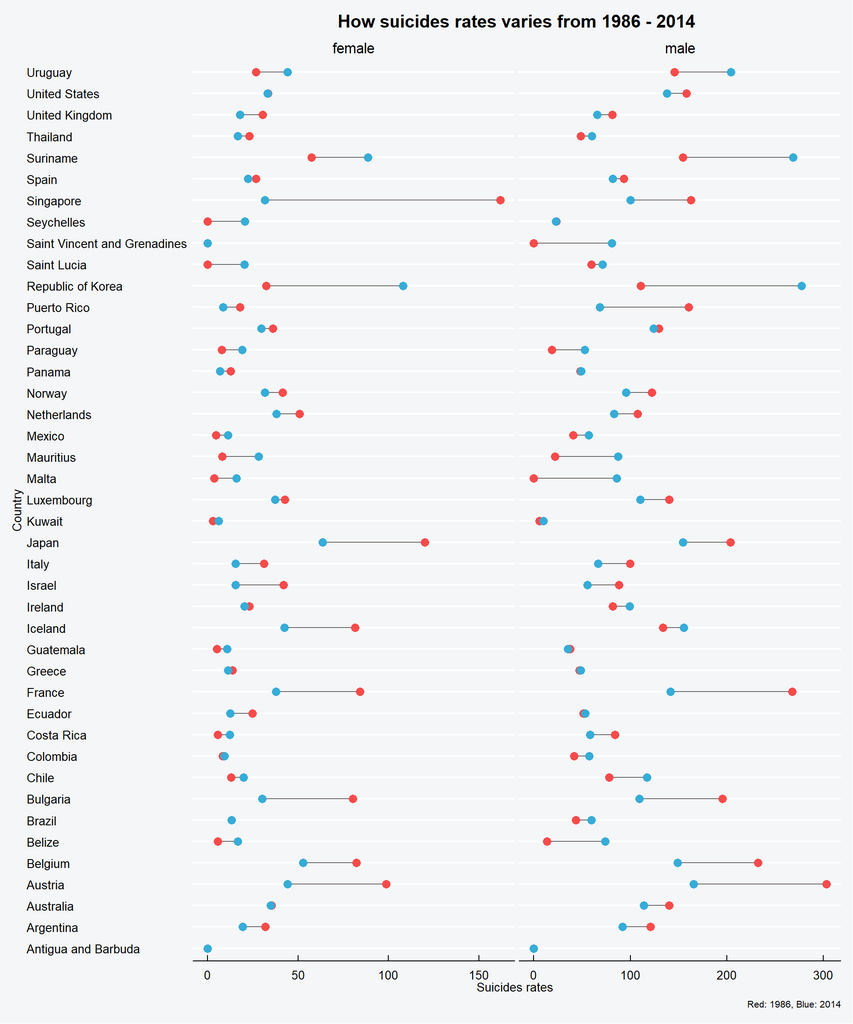

Let me give you a simple trick to read this plot : if the red dot is located at the right then the suicide rate dropped of the distance between the red dot and blue dot. You interpret it the same for the blue. The blue dot is the suicides rate in 2014, the red the suicides rate in 1986.

We see on this graphic that th suicides rates of men are twice higher than the women’s (as shown in the x axis).

The women suicides rates in Singapour was really high in 1986 but it drops significantly in 28 years. In Korea we see the inverse (sadly).

# Multivariate Analysis

## En 1986

```r
pca_data <- suicide %>% group_by(country, year) %>%
summarize(nb_occurence = n(), sum_gdp = sum(gdp),
          population = sum(population), suicide = sum(suicides.100k.pop),
          gdp_real = sum_gdp/nb_occurence, gdp_per_capita = gdp_real/population)
pca_1986 <- pca_data %>% filter(year == 1986) %>% select(country, population, suicide, gdp_per_capita) %>%
data.frame(row.names = "country")
```

```r
library(FactoMineR)
```

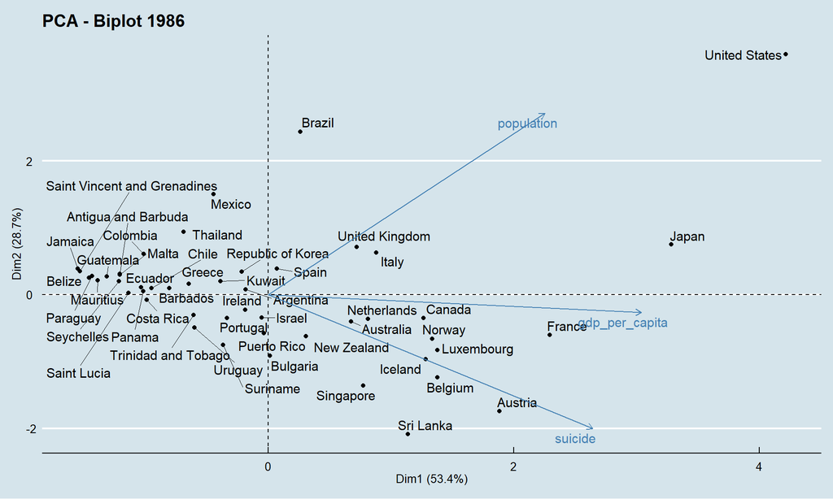

The first dimension explains 53% of the variability among the countries. It is positively influenced by the 3 variables, but GDP per capita has a stronger influence on this first dimension.  
The second dimension explains 29% of information and is strongly influenced positively by the population and negatively by suicide. These two axes allow us to say that a country whose coordinates are located to the right of this graph is a rich country. Similarly a country located at the top is a populated country. If the country is located at the bottom of the graph the higher is the proportion of suicide in that country. ## In 2015 Let’s see how the situation of countries has changed in 29 years

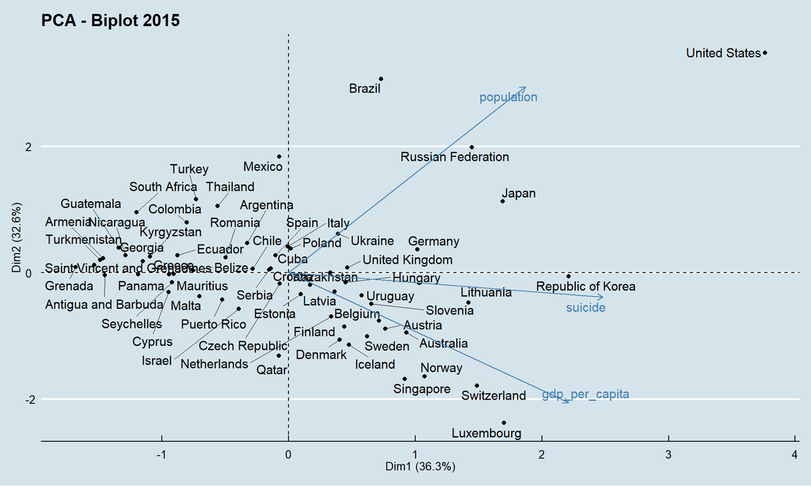

Compared to the results obtained in 1986, the two dimensions have about the same importance. Suicide is not as important as it was in 1986. The direcion of arrows has changed: the more a country is on the right, the higher its suicide rate. The countries on the top right are countries with a large population and a high suicide rate. While the countries at the bottom have a small population but a very high GDP per capita.

# Link between wealth and suicide

Is there any link between how rich a country is and how high is the suicide rate?

```r
data <- suicide %>% group_by(country, year) %>%
summarize(nb = n(), pop = sum(population), suicide_100k = sum(suicides.100k.pop),
         gdp = sum(gdp), real_gdp = gdp/nb, gdp_per_capita = real_gdp/pop)
highchart() %>% hc_title(text = "Scatter plot of suicide rate and GDP per capita in 1986") %>%
  hc_add_series(data %>% filter(year == 1986), name = '1986', type = "scatter",
                hcaes(x = gdp_per_capita, y = suicide_100k))
```

[interactive chart not shown]

Let’s use ggplot2 to estimate a linear trend between the two variables for three periods of time.

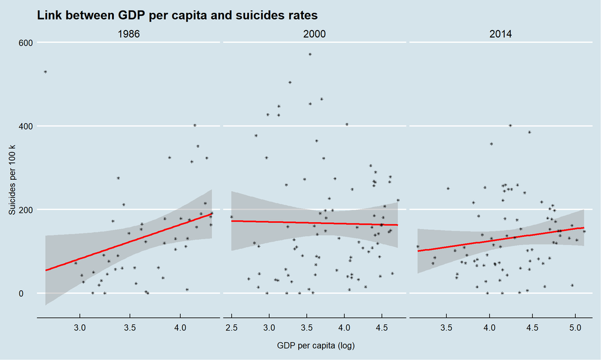

There is a change of trend over time. In 1986 the relationship between suicide numbers and national wealth per capita seems to be positive and growing. In 2000 this same relationship becomes slightly decreasing and it seems to increase a little bit in 2014.  
The linear relationship is not clearly stated.

To further explore this relationship, segment GDP per capita into groups to represent them in a way we can see variability among the group.

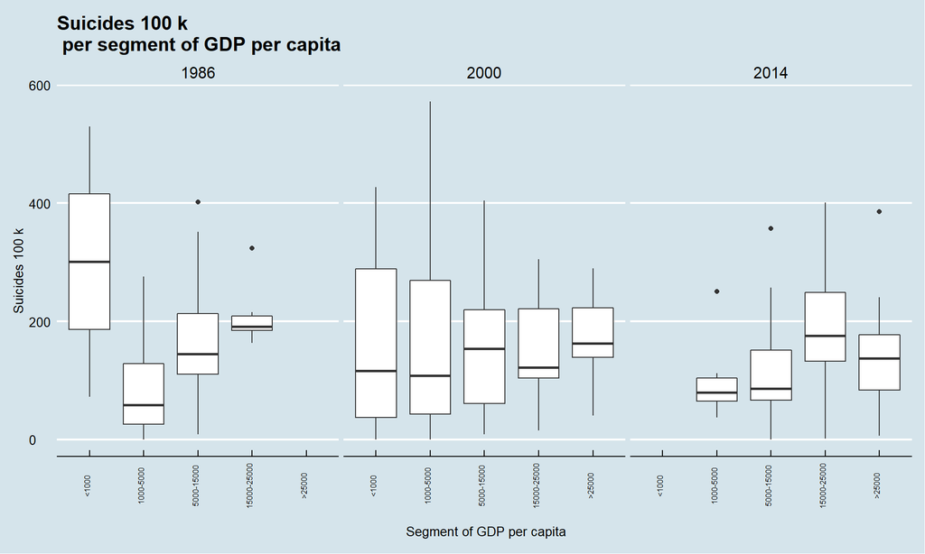

```r
comp <- data %>%
mutate(intervalle = cut(gdp_per_capita, breaks = c(0,1000,5000,15000,25000, 200000),
                       labels = c("<1000", "1000-5000", "5000-15000", "15000-25000",">25000"),
                       include.lowest = FALSE))
```

We must be careful with the interpretation for two reasons: * For every year we do not have all the countries * The nominal GDP per capita increases over time: for example in 1986 Albania had a per capita GDP of about 700 dollars whereas today it is [12700] (http://perspective.usherbrooke.ca /bilan/tend/ALB/fr/NY.GDP.PCAP.PP.CD.html). The results for 2000 are more accurate because all the countries present were able to be represented in each tranche.